# Homework 2 – Question 2

```r
library(ggplot2)
load("../data/RainData.RData")   # data.frame `dati` (stations of all years) and `grid`
```

# Question 2: choice of p in the IDW estimator

## Method

The power $p$ of the IDW estimator controls how fast the weight of a station decreases with the distance: with $p$ close to 0 all stations count almost the same and the prediction is close to the overall mean; with a large $p$ only the nearest stations matter and the surface follows the observations closely. For each year (1973, 1974 and 1980), we choose $p$ by leave-one-out cross-validation: each station is removed in turn and predicted from the others, and we keep the $p$ with the smallest RMSE, searching on a grid from 0.25 to 8 and refining around the minimum. The result is compared with a simple reference, the mean of the other stations.

```r
loocv_idw <- function(d, p_grid = seq(0.25, 8, by = 0.25)) {
  z  <- d$totanno; n <- length(z)
  Dm <- as.matrix(dist(cbind(d$XUTM, d$YUTM))); diag(Dm) <- Inf   # a station never predicts itself
  pred <- function(p) { W <- Dm^(-p); as.vector(W %*% z) / rowSums(W) }
  rmse <- function(p) sqrt(mean((z - pred(p))^2))
  curve <- data.frame(p = p_grid, RMSE = sapply(p_grid, rmse))
  p0  <- curve$p[which.min(curve$RMSE)]
  opt <- optimize(rmse, c(max(0.01, p0 - 0.25), p0 + 0.25))        # refinement around the minimum
  ref <- sqrt(mean((z - (sum(z) - z) / (n - 1))^2))                 # mean of the other stations
  near <- curve$p[curve$RMSE <= 1.01 * opt$objective]               # p giving an RMSE within 1 % of the best
  pr <- pred(opt$minimum)
  hi <- z > quantile(z, 0.9); lo <- z < quantile(z, 0.1)
  list(curve = curve, p_opt = opt$minimum, rmse = opt$objective, ref = ref,
       mae = mean(abs(z - pr)), n = n, p_low = min(near), p_high = max(near),
       r_small = curve$RMSE[1], r_large = curve$RMSE[nrow(curve)],
       cor = cor(z, pr), bias_hi = mean(pr[hi] - z[hi]), bias_lo = mean(pr[lo] - z[lo]),
       cv = data.frame(obs = z, pred = pr))
}

years <- c(1973, 1974, 1980)
q2 <- lapply(years, function(y) loocv_idw(subset(dati, anno == y)))
names(q2) <- years
get <- function(f) sapply(q2, `[[`, f)
```

## Results

```r
q2_tab <- data.frame(
  Year = years,
  Stations = get("n"),
  `Optimal p` = round(get("p_opt"), 2),
  `p within 1 % of the best RMSE` = sapply(q2, function(r) paste0(r$p_low, " - ", r$p_high)),
  RMSE = round(get("rmse")),
  MAE = round(get("mae")),
  `RMSE of the reference` = round(get("ref")),
  `MSE reduction (%)` = round(100 * (1 - get("rmse")^2 / get("ref")^2)),
  check.names = FALSE)
knitr::kable(q2_tab, row.names = FALSE)
```

| Year | Stations | Optimal p | p within 1 % of the best RMSE | RMSE | MAE | RMSE of the reference | MSE reduction (%) |
| --- | --- | --- | --- | --- | --- | --- | --- |
| 1973 | 188 | 3.13 | 2.75 - 3.75 | 309 | 243 | 465 | 56 |
| 1974 | 187 | 3.45 | 3 - 4.25 | 255 | 198 | 408 | 61 |
| 1980 | 178 | 2.62 | 2.25 - 3 | 358 | 267 | 486 | 46 |

The table gives, for each year, the number of stations, the optimal $p$, the range of $p$ whose RMSE is less than 1 % above the best one, the cross-validation RMSE and MAE (in mm), the RMSE of the reference and the reduction of the mean squared error obtained with the IDW compared with the reference. The optimal $p$ is 3.13 in 1973, 3.45 in 1974 and 2.62 in 1980. In each year the IDW predicts clearly better than the reference: the RMSE goes from 465, 408 and 486 mm to 309, 255 and 358 mm, which is a reduction of the mean squared error of 46 to 61 %.

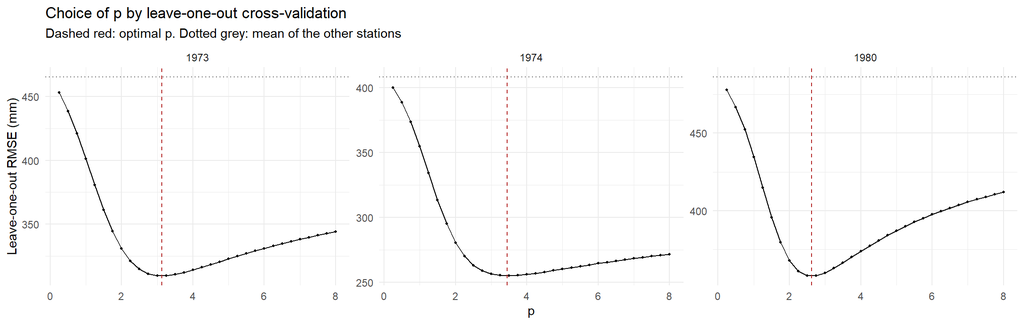

```r
curves <- do.call(rbind, lapply(years, function(y) cbind(q2[[as.character(y)]]$curve, Year = y)))
marks  <- data.frame(Year = years, p_opt = get("p_opt"), ref = get("ref"))
ggplot(curves, aes(p, RMSE)) +
  geom_line() + geom_point(size = 0.8) +
  geom_vline(data = marks, aes(xintercept = p_opt), colour = "firebrick", linetype = 2) +
  geom_hline(data = marks, aes(yintercept = ref), colour = "grey40", linetype = 3) +
  facet_wrap(~ Year, nrow = 1, scales = "free_y") +
  labs(x = "p", y = "Leave-one-out RMSE (mm)",
       title = "Choice of p by leave-one-out cross-validation",
       subtitle = "Dashed red: optimal p. Dotted grey: mean of the other stations") +
  theme_minimal()
```

*Figure 1: leave-one-out RMSE as a function of p, one panel per year (each panel has its own vertical scale). The dashed red line is the optimal p and the dotted grey line is the RMSE of the reference.*

**Comment on Figure 1.** In each year the RMSE reaches a clear minimum, at $p$ = 3.13, 3.45 and 2.62. The curve is flat around it: the values of $p$ within 1 % of the best RMSE form an interval about 1 unit wide (see the table), so the choice of $p$ is not critical.

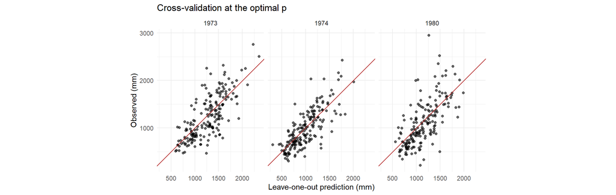

```r
cvs <- do.call(rbind, lapply(years, function(y) cbind(q2[[as.character(y)]]$cv, Year = y)))
ggplot(cvs, aes(pred, obs)) +
  geom_point(alpha = 0.6) + geom_abline(colour = "firebrick") +
  facet_wrap(~ Year, nrow = 1) + coord_equal() +
  labs(x = "Leave-one-out prediction (mm)", y = "Observed (mm)",
       title = "Cross-validation at the optimal p") +
  theme_minimal()
```

*Figure 2: observed rainfall against the leave-one-out prediction at the optimal p. The red line is the line prediction = observation.*

**Comment on Figure 2.** The points are spread around the red line, with a correlation between observation and prediction of 0.75 in 1973, 0.78 in 1974 and 0.68 in 1980. The wettest stations (top 10 % of the observed values) are under-predicted, by 417, 348 and 601 mm on average, and the driest ones (bottom 10 %) are over-predicted, by 251, 224 and 410 mm.

The optimal values of $p$ are used in the next question to map the rainfall on the prediction grid.